# US Elections 2020

Hakob Hakobyan, Rafayel Antonyan, Sargis Hakobyan

2022-12-23

### *Part1*

## Creating a dataset using BBC playlist data

For our project we have chosen a BBC playlist representing US president elections news in 2020.

### Activation of libraries

```r
library(httr)
library(jsonlite)
library(here)
library(tidyverse)
library(stringr)
library(tidytext)
```

### Scrapping snippets and content deteils

```r
key <- "AIzaSyBbspEjtv2ZXSXUR60ADZmSXEJJWxzwkAs"
playlist_id<-"PLS3XGZxi7cBVLrHAQVzG0MPSY_W3Hiwm0"
base <- "https://www.googleapis.com/youtube/v3/"

nextPageToken <- ""
upload.df <- NULL
pageInfo <- NULL

while (!is.null(nextPageToken)) {

  api_params <-
    paste(paste0("key=", key),
          paste0("playlistId=", playlist_id),
          "part=snippet,contentDetails,status",
          "maxResults=50",
          sep = "&")

  if (nextPageToken != "") {
    api_params <- paste0(api_params,
                         "&pageToken=",nextPageToken)
  }

  api_call <- paste0(base, "playlistItems", "?", api_params)
  api_result <- GET(api_call)
  json_result <- content(api_result, "text", encoding="UTF-8")
  upload.json <- fromJSON(json_result, flatten = T)

  nextPageToken <- upload.json$nextPageToken
  pageInfo <- upload.json$pageInfo

  curr.df <- as.data.frame(upload.json$items)
  if (is.null(upload.df)) {
    upload.df <- curr.df
  } else {
    upload.df <- bind_rows(upload.df, curr.df)
  }
}
```

### Scrapping video statistics

```r
video.df<- NULL
for (i in 1:nrow(upload.df)) {

  video_id <- upload.df$contentDetails.videoId[i]
  api_params <-
    paste(paste0("key=", key),
          paste0("id=", video_id),
          "part=id,statistics,contentDetails",
          sep = "&")

  api_call <- paste0(base, "videos", "?", api_params)
  api_result <- GET(api_call)
  json_result <- content(api_result, "text", encoding="UTF-8")
  video.json <- fromJSON(json_result, flatten = T)

  curr.df <- as.data.frame(video.json$items)

  if (is.null(video.df)) {
    video.df <- curr.df
  } else {
    video.df <- bind_rows(video.df, curr.df)
  }
}
```

### Removing duplicates and unavailable videos

```r
upload.df<-upload.df[!is.na(upload.df$snippet.thumbnails.default.url),]
upload.df<-upload.df %>% distinct(contentDetails.videoId, .keep_all = TRUE)
video.df<-video.df %>% distinct(id, .keep_all = TRUE)
```

### Merging the two datasets

```r
video_final.df <- merge(x = upload.df,
                        y = video.df,
                        by.x = "contentDetails.videoId",
                        by.y = "id",
                        all.x = FALSE,
                        all.y = TRUE)
video_final.tb<-tibble(video_final.df)
```

### Text mining

```r
video_final.tb <- video_final.tb %>%
  unnest_tokens(word, snippet.description) %>%
  select(contentDetails.videoId, snippet.publishedAt, snippet.title, word,
         contentDetails.duration, contentDetails.caption,
         statistics.viewCount, statistics.likeCount, statistics.commentCount)
```

### Sentiment and informative analysis of each document

```r
video_last <- video_final.tb %>%
  count(snippet.title, word) %>%
  filter(!str_detect(word, "\\d+")) %>%
  anti_join(stop_words, by = "word")


getafinn<- video_last%>%
  inner_join(get_sentiments("afinn"), by = "word")%>%
  group_by(snippet.title) %>%
  summarize(afinn.value = sum(n * abs(value)))

getbing<-video_last%>%
  inner_join(get_sentiments("bing"),by="word")%>%
  mutate(value = recode(sentiment, negative=-1,positive=1))%>%
  group_by(snippet.title) %>%
  summarize(bing.value = sum(n * abs(value)))

gettf_idf <-  video_last%>%count(snippet.title, word)%>%
  bind_tf_idf(word,snippet.title,n) %>%
  group_by(snippet.title) %>%
  summarize(tf=mean(tf),idf=mean(idf),tf_idf=mean(tf_idf))
```

### Merging datasets

```r
db <- merge(x = getafinn,
                        y = gettf_idf,
                        by.x = "snippet.title",
                        by.y = "snippet.title",
                        all.x = FALSE,
                        all.y = TRUE)

db<- merge(x = getbing,
                        y = db,
                        by.x = "snippet.title",
                        by.y = "snippet.title",
                        all.x = FALSE,
                        all.y = TRUE)

db<- merge(x = video_final.df,
                        y = db,
                        by.x = "snippet.title",
                        by.y = "snippet.title",
                        all.x = FALSE,
                        all.y = TRUE)

db<- db%>%
  select(Title=snippet.title, Views=statistics.viewCount,Likes=statistics.likeCount,
        Comments=statistics.commentCount, tf, idf, tf_idf, bing.value, afinn.value)
```

### Creating new metrics

We create a new estimator **af.bi.value** (the sum of afinn and bing values) which may represent the **sentiment** of each document better.

```r
db<- db %>%
  replace_na(list(bing.value = 0, afinn.value = 0)) %>%
  mutate(af.bi.value = bing.value + afinn.value)
```

Creating another statistic metric **Engagement** which is the sum of likes and comments of a video, and **Eng.view** which is the relation of Engagement and Views.

```r
db$Views<- as.numeric(db$Views)
db$Likes<- as.numeric(db$Likes)
db$Comments<- as.numeric(db$Comments)

db<- db %>%
  mutate(Engagement = Likes + Comments)

db<- db%>%
  mutate(Eng.view = Engagement/Views)
```

### Saving our dataset

```r
write.csv(db, file = "db.csv", row.names = FALSE)
```

### *Part 2*

```r
load("C:/Users/rafoa/Desktop/Final/db.RData")
```

## Simple Linear Regression

```r
reg1<-lm(Eng.view ~ tf_idf, data=db)
summary(reg1)
```

```
##
## Call:
## lm(formula = Eng.view ~ tf_idf, data = db)
##
## Residuals:
##        Min         1Q     Median         3Q        Max
## -0.0144732 -0.0065758 -0.0008781  0.0047897  0.0314638
##
## Coefficients:
##             Estimate Std. Error t value Pr(>|t|)
## (Intercept)  0.01425    0.00120  11.875   <2e-16 ***
## tf_idf       0.02283    0.01180   1.935    0.054 .
## ---
## Signif. codes:  0 '***' 0.001 '**' 0.01 '*' 0.05 '.' 0.1 ' ' 1
##
## Residual standard error: 0.008244 on 294 degrees of freedom
## Multiple R-squared:  0.01257,    Adjusted R-squared:  0.009213
## F-statistic: 3.743 on 1 and 294 DF,  p-value: 0.05399
```

```r
reg2<-lm(Eng.view ~ af.bi.value, data=db)
summary(reg2)
```

```
##
## Call:
## lm(formula = Eng.view ~ af.bi.value, data = db)
##
## Residuals:
##        Min         1Q     Median         3Q        Max
## -0.0168975 -0.0061080 -0.0009677  0.0049670  0.0294465
##
## Coefficients:
##              Estimate Std. Error t value Pr(>|t|)
## (Intercept) 1.400e-02  6.553e-04  21.368  < 2e-16 ***
## af.bi.value 2.663e-04  5.215e-05   5.107 5.88e-07 ***
## ---
## Signif. codes:  0 '***' 0.001 '**' 0.01 '*' 0.05 '.' 0.1 ' ' 1
##
## Residual standard error: 0.007951 on 294 degrees of freedom
## Multiple R-squared:  0.0815, Adjusted R-squared:  0.07837
## F-statistic: 26.09 on 1 and 294 DF,  p-value: 5.882e-07
```

```r
reg3<-lm(Eng.view ~ afinn.value, data=db)
summary(reg3)
```

```
##
## Call:
## lm(formula = Eng.view ~ afinn.value, data = db)
##
## Residuals:
##       Min        1Q    Median        3Q       Max
## -0.016978 -0.006277 -0.001144  0.004984  0.030753
##
## Coefficients:
##              Estimate Std. Error t value Pr(>|t|)
## (Intercept) 1.452e-02  6.298e-04  23.060  < 2e-16 ***
## afinn.value 3.612e-04  8.241e-05   4.383 1.63e-05 ***
## ---
## Signif. codes:  0 '***' 0.001 '**' 0.01 '*' 0.05 '.' 0.1 ' ' 1
##
## Residual standard error: 0.008038 on 294 degrees of freedom
## Multiple R-squared:  0.06134,    Adjusted R-squared:  0.05815
## F-statistic: 19.21 on 1 and 294 DF,  p-value: 1.629e-05
```

```r
reg4<-lm(Eng.view ~ bing.value, data=db)
summary(reg4)
```

```
##
## Call:
## lm(formula = Eng.view ~ bing.value, data = db)
##
## Residuals:
##       Min        1Q    Median        3Q       Max
## -0.015713 -0.006040 -0.001041  0.004665  0.027335
##
## Coefficients:
##              Estimate Std. Error t value Pr(>|t|)
## (Intercept) 0.0136670  0.0006640  20.583  < 2e-16 ***
## bing.value  0.0007157  0.0001270   5.635 4.11e-08 ***
## ---
## Signif. codes:  0 '***' 0.001 '**' 0.01 '*' 0.05 '.' 0.1 ' ' 1
##
## Residual standard error: 0.007882 on 294 degrees of freedom
## Multiple R-squared:  0.09747,    Adjusted R-squared:  0.0944
## F-statistic: 31.75 on 1 and 294 DF,  p-value: 4.106e-08
```

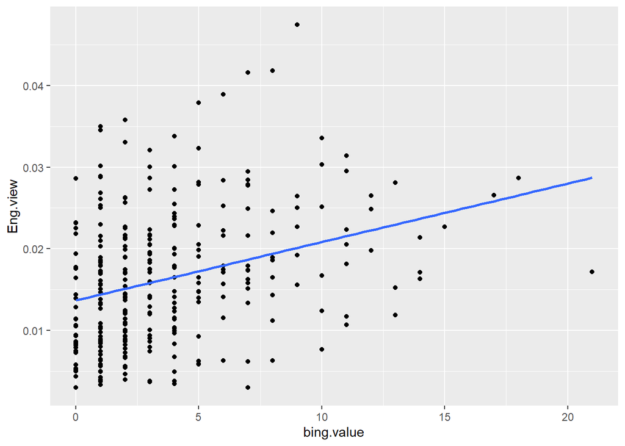

```r
ggplot(tibble(db))+geom_point(aes(x = bing.value,y=Eng.view, ))+
  geom_smooth(aes(x = bing.value, y=Eng.view ), method="lm", se=FALSE)
```

#### Comments based on statical results

As R-squared value for Reg4 is the highest we comment only Reg4 model results.

- The coefficient of slope is 0.0007157, which means an increase in bing value by 1 unit increase Eng.views by 0.0007157 on average.
- The coefficient of slope is significant and has a p-value very close to 0, so is the significance of the intercept coefficient.
- As R-squared value for Reg4 is 0.09747 closer to 0, this model is not so good, which means that variation of a dependent variable is poorly explained by the independent variable in a regression. But it is still better then the rest 3 models.

## Multiple Linear Regression

```r
mlreg1<-lm(Eng.view ~ tf_idf+afinn.value+bing.value, data=db)
summary(mlreg1)
```

```
##
## Call:
## lm(formula = Eng.view ~ tf_idf + afinn.value + bing.value, data = db)
##
## Residuals:
##       Min        1Q    Median        3Q       Max
## -0.015313 -0.005254 -0.001329  0.004504  0.026873
##
## Coefficients:
##              Estimate Std. Error t value Pr(>|t|)
## (Intercept) 0.0061953  0.0015175   4.082 5.76e-05 ***
## tf_idf      0.0661815  0.0121905   5.429 1.19e-07 ***
## afinn.value 0.0000305  0.0001344   0.227    0.821
## bing.value  0.0010188  0.0002160   4.717 3.71e-06 ***
## ---
## Signif. codes:  0 '***' 0.001 '**' 0.01 '*' 0.05 '.' 0.1 ' ' 1
##
## Residual standard error: 0.007537 on 292 degrees of freedom
## Multiple R-squared:  0.1804, Adjusted R-squared:  0.1719
## F-statistic: 21.42 on 3 and 292 DF,  p-value: 1.444e-12
```

```r
mlreg2<-lm(Eng.view ~ tf_idf+bing.value, data=db)
summary(mlreg2)
```

```
##
## Call:
## lm(formula = Eng.view ~ tf_idf + bing.value, data = db)
##
## Residuals:
##       Min        1Q    Median        3Q       Max
## -0.014911 -0.005229 -0.001330  0.004500  0.026697
##
## Coefficients:
##              Estimate Std. Error t value Pr(>|t|)
## (Intercept) 0.0062302  0.0015073   4.133 4.67e-05 ***
## tf_idf      0.0659443  0.0121259   5.438 1.14e-07 ***
## bing.value  0.0010568  0.0001365   7.741 1.62e-13 ***
## ---
## Signif. codes:  0 '***' 0.001 '**' 0.01 '*' 0.05 '.' 0.1 ' ' 1
##
## Residual standard error: 0.007525 on 293 degrees of freedom
## Multiple R-squared:  0.1802, Adjusted R-squared:  0.1746
## F-statistic: 32.21 on 2 and 293 DF,  p-value: 2.276e-13
```

```r
mlreg3<-lm(Eng.view ~ tf_idf+af.bi.value, data=db)
summary(mlreg3)
```

```
##
## Call:
## lm(formula = Eng.view ~ tf_idf + af.bi.value, data = db)
##
## Residuals:
##       Min        1Q    Median        3Q       Max
## -0.017483 -0.005529 -0.001156  0.004926  0.029732
##
## Coefficients:
##              Estimate Std. Error t value Pr(>|t|)
## (Intercept) 7.055e-03  1.510e-03   4.673 4.53e-06 ***
## tf_idf      6.215e-02  1.228e-02   5.062 7.35e-07 ***
## af.bi.value 3.959e-04  5.625e-05   7.038 1.39e-11 ***
## ---
## Signif. codes:  0 '***' 0.001 '**' 0.01 '*' 0.05 '.' 0.1 ' ' 1
##
## Residual standard error: 0.007638 on 293 degrees of freedom
## Multiple R-squared:  0.1554, Adjusted R-squared:  0.1496
## F-statistic: 26.95 on 2 and 293 DF,  p-value: 1.809e-11
```

## Binary Logistic Regression

Let’s define a new dummy variable “Interest” that will express the interest of viewers based on “likes” and “comment” measures. It will have two values: 1 for videos with high interest from viewers, and 0 for videos with low interest from viewers. The variable Interest can be constructed in a different way. Here we construct it based on a visual analysis of the “likes/view” and “comment/ view” scatter plot and heuristic thresholds.

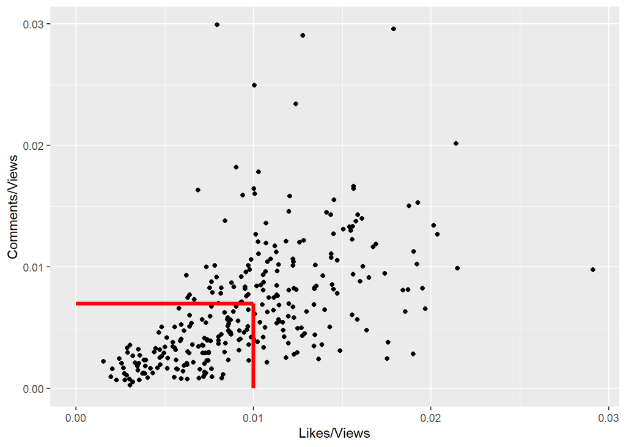

```r
ggplot(tibble(db))+geom_point(aes(x = Likes/Views,y=Comments/Views))+
  geom_segment(aes(x = 0.01, y = 0, xend = 0.01, yend = 0.007), color ="red", linewidth =1.5)+
  geom_segment(aes(x = 0, y = 0.007, xend = 0.01, yend = 0.007), color ="red", linewidth =1.5)
```

We construct “interest” variable by following expression:

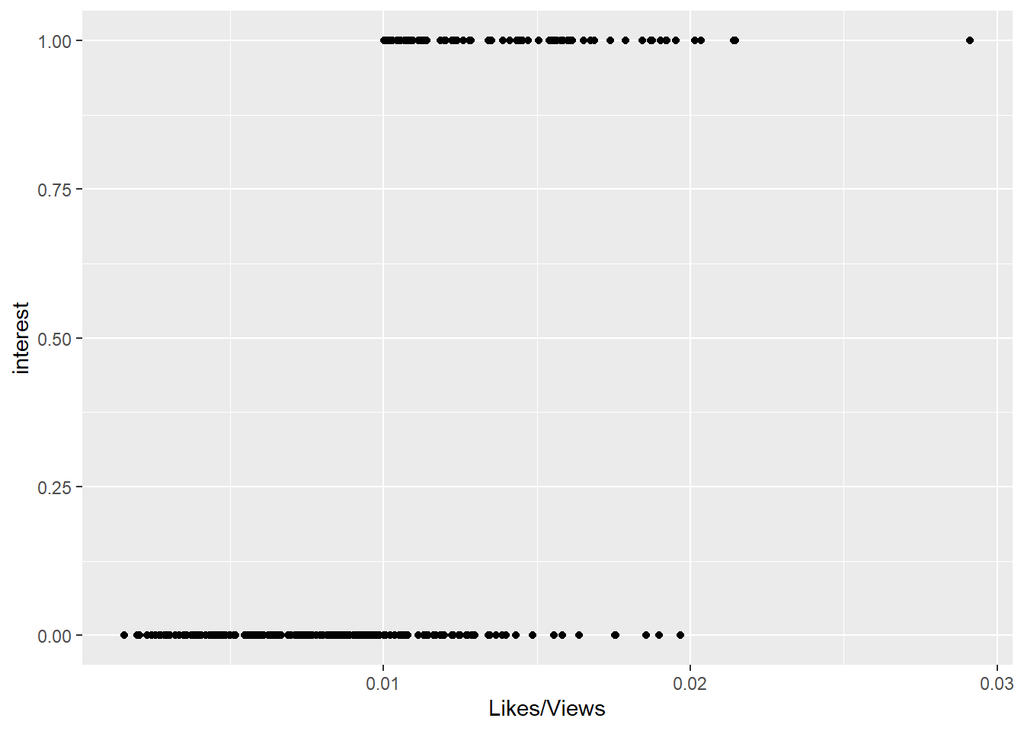

```r
db<- db%>%mutate(interest = case_when( Likes/Views>=0.01 & Comments/Views>=0.007 ~ 1,
                                             TRUE ~0))
ggplot(tibble(db))+geom_point(aes(x = Likes/Views,y=interest))
```

Now, if we want to use the dummy variable “interest” as a dependent we must turn to general linear models, particularly to the logistic model. For general linear models in R we use glm function.

The smaller AIC is the better is the model.

```r
logM1<-glm(interest ~ tf_idf + afinn.value + bing.value, data = db, family = "binomial")
summary(logM1)
```

```
##
## Call:
## glm(formula = interest ~ tf_idf + afinn.value + bing.value, family = "binomial",
##     data = db)
##
## Deviance Residuals:
##     Min       1Q   Median       3Q      Max
## -2.1330  -0.7611  -0.6176   1.0316   2.0402
##
## Coefficients:
##             Estimate Std. Error z value Pr(>|z|)
## (Intercept) -3.14270    0.50455  -6.229 4.70e-10 ***
## tf_idf      13.28404    3.68550   3.604 0.000313 ***
## afinn.value -0.02916    0.04099  -0.711 0.476802
## bing.value   0.27309    0.06691   4.082 4.47e-05 ***
## ---
## Signif. codes:  0 '***' 0.001 '**' 0.01 '*' 0.05 '.' 0.1 ' ' 1
##
## (Dispersion parameter for binomial family taken to be 1)
##
##     Null deviance: 353.12  on 295  degrees of freedom
## Residual deviance: 318.51  on 292  degrees of freedom
## AIC: 326.51
##
## Number of Fisher Scoring iterations: 4
```

```r
logM2<-glm(interest ~ tf_idf + bing.value, data = db, family = "binomial")
summary(logM2)
```

```
##
## Call:
## glm(formula = interest ~ tf_idf + bing.value, family = "binomial",
##     data = db)
##
## Deviance Residuals:
##     Min       1Q   Median       3Q      Max
## -2.3020  -0.7526  -0.6224   1.0350   2.0520
##
## Coefficients:
##             Estimate Std. Error z value Pr(>|z|)
## (Intercept) -3.18353    0.50367  -6.321 2.60e-10 ***
## tf_idf      13.54582    3.68028   3.681 0.000233 ***
## bing.value   0.23831    0.04513   5.281 1.29e-07 ***
## ---
## Signif. codes:  0 '***' 0.001 '**' 0.01 '*' 0.05 '.' 0.1 ' ' 1
##
## (Dispersion parameter for binomial family taken to be 1)
##
##     Null deviance: 353.12  on 295  degrees of freedom
## Residual deviance: 319.02  on 293  degrees of freedom
## AIC: 325.02
##
## Number of Fisher Scoring iterations: 4
```

As we can see from the results AIC of model 2 is smaller, so logM2 is the better model in this case.

We can express each of the coefficients as an odds ratio:

```r
exp(coef(logM2))
```

```
##  (Intercept)       tf_idf   bing.value
## 4.143903e-02 7.636135e+05 1.269104e+00
```

So we conclude that tf_idf value which represents the informativeness of a video has the most influence on the interest of a video.

## Pseudo R square measures

While no exact equivalent to the R2 of linear regression exists, the McFadden R2 index can be used to assess the model fit.

```r
library(pscl)
pR2(logM1)
```

```
## fitting null model for pseudo-r2
```

```
##           llh       llhNull            G2      McFadden          r2ML
## -159.25435226 -176.56149715   34.61428978    0.09802332    0.11036158
##          r2CU
##    0.15840960
```

```r
pR2(logM2)
```

```
## fitting null model for pseudo-r2
```

```
##           llh       llhNull            G2      McFadden          r2ML
## -159.51004323 -176.56149715   34.10290784    0.09657515    0.10882327
##          r2CU
##    0.15620157
```

The higher pseudo R-squared indicates which model better predicts the outcome. Although we can see pseudo-r2 of logM1 is slightly higher than that of logM2, we still choose logM2 to logM1 based on their AICs.

## Accuracy calculation

We will be splitting the data into the test and train using the createDataPartition() function from the caret package in R. We will train the model using the training dataset and predict the values on the test dataset. To train the logistic model, we will be using glm() function.

```r
# Loading caret library
library(caret)
# Splitting the data into train and test
set.seed(777)
index <- createDataPartition(db$interest, p = .70, list = FALSE)
train <- db[index, ]
test <- db[-index, ]

# Training the model
logM2train<-glm(interest ~ tf_idf + bing.value, data = train, family = "binomial")
summary(logM2train)
```

```
##
## Call:
## glm(formula = interest ~ tf_idf + bing.value, family = "binomial",
##     data = train)
##
## Deviance Residuals:
##     Min       1Q   Median       3Q      Max
## -1.8726  -0.7514  -0.6450   1.0853   1.9865
##
## Coefficients:
##             Estimate Std. Error z value Pr(>|z|)
## (Intercept) -2.79055    0.54749  -5.097 3.45e-07 ***
## tf_idf      11.02400    4.00983   2.749 0.005973 **
## bing.value   0.17805    0.04983   3.573 0.000353 ***
## ---
## Signif. codes:  0 '***' 0.001 '**' 0.01 '*' 0.05 '.' 0.1 ' ' 1
##
## (Dispersion parameter for binomial family taken to be 1)
##
##     Null deviance: 240.30  on 207  degrees of freedom
## Residual deviance: 224.66  on 205  degrees of freedom
## AIC: 230.66
##
## Number of Fisher Scoring iterations: 4
```

```r
# Predicting in the test dataset
pred_prob <- predict(logM2train, test, type = "response")
```

Before we create a contingency table, we need to convert the probability into the two levels of interest: 0 and 1. To get these values, we will be using a simple ifelse() function and will create a new variable in the train data by the name pred_interest.

#### Converting probability to interest values in the training dataset

```r
# Converting from probability to actual output
train$pred_interest <- ifelse(logM2train$fitted.values >= 0.3, 1, 0)

# Generating the classification table
ctab_train <- table(train$interest, train$pred_interest)
ctab_train
```

```
##
##       0   1
##   0 120  33
##   1  28  27
```

```r
# Converting from probability to actual output
test$pred_interest <- ifelse(pred_prob >= 0.3, 1, 0)

# Generating the classification table
ctab_test <- table(test$interest, test$pred_interest)
ctab_test
```

```
##
##      0  1
##   0 50  9
##   1 13 16
```

This is the confusion matrix of our model.

#### Train and Test Accuracy

```r
# Accuracy in Training dataset
accuracy_train <- sum(diag(ctab_train))/sum(ctab_train)*100
accuracy_train
```

```
## [1] 70.67308
```

```r
# Accuracy in Test dataset
accuracy_test <- sum(diag(ctab_test))/sum(ctab_test)*100
accuracy_test
```

```
## [1] 75
```

A model is considered fairly good if the model *accuracy is greater than 70%.*

The over all correct classification accuracy in test dataset is **75%** so our prediction model is good.

### Creating confusion matrix using other method

```r
test$pred_interest<-as_factor(test$pred_interest)
test$interest<-as_factor(test$interest)
confMx <- confusionMatrix(data=test$pred_interest, reference = test$interest)
confMx
```

```
## Confusion Matrix and Statistics
##
##           Reference
## Prediction  0  1
##          0 50 13
##          1  9 16
##
##                Accuracy : 0.75
##                  95% CI : (0.6463, 0.8362)
##     No Information Rate : 0.6705
##     P-Value [Acc > NIR] : 0.06782
##
##                   Kappa : 0.4137
##
##  Mcnemar's Test P-Value : 0.52243
##
##             Sensitivity : 0.8475
##             Specificity : 0.5517
##          Pos Pred Value : 0.7937
##          Neg Pred Value : 0.6400
##              Prevalence : 0.6705
##          Detection Rate : 0.5682
##    Detection Prevalence : 0.7159
##       Balanced Accuracy : 0.6996
##
##        'Positive' Class : 0
##
```

## ROC Curve

The area under the curve(AUC) is the measure that represents ROC(Receiver Operating Characteristic) curve. This ROC curve is a line plot that is drawn between the Sensitivity and (1 – Specificity) Or between TPR and TNR. This graph is then used to generate the AUC value. An AUC value of greater than .70 indicates a good model.

```r
library(pROC)
roc <- roc(train$interest, logM2train$fitted.values)
auc(roc)
```

```
## Area under the curve: 0.7035
```

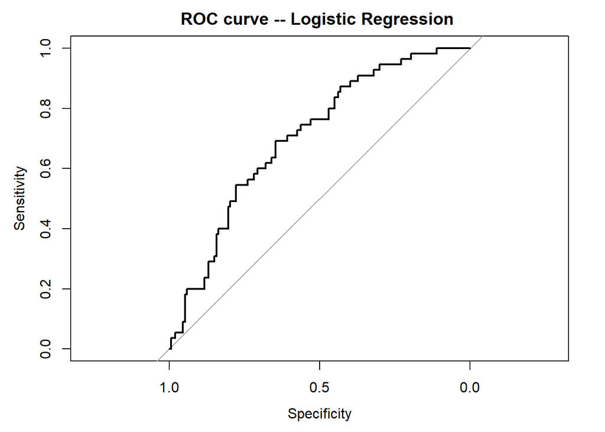

```r
plot(roc ,main ="ROC curve -- Logistic Regression ")
```

As the AUC value (Area under the curve) we got is 0.70, we can conclude that we have a good model.

## Decission trees

### Building the model

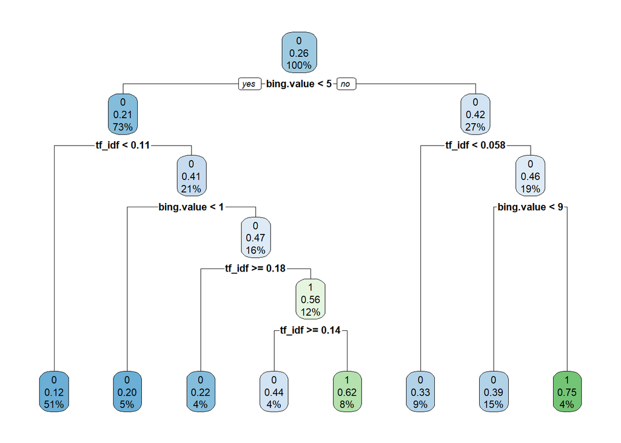

```r
library(rpart)
library(rpart.plot)
dtModel <- rpart(interest~ tf_idf + bing.value, data = train, method = 'class')
rpart.plot(dtModel, extra = 106)
```

### Making a Prediction

```r
predicted <-predict(dtModel, test, type = 'class')

table_mat <- table(test$interest, predicted)
table_mat
```

```
##    predicted
##      0  1
##   0 53  6
##   1 24  5
```

### Measuring Performance

```r
accuracy_Test <- sum(diag(table_mat)) / sum(table_mat)*100
print(paste('Accuracy for test', accuracy_Test))
```

```
## [1] "Accuracy for test 65.9090909090909"
```

## Conclusion

During this project we have built **Simple** and **Multiple Linear Regression** models, used **Binary Logistic Regression** and **Decision Trees** for interpreting behavior of the auditorium of BBC playlist called *US president elections* .

The accuracy of our **Decision tree model** is **65.9%**, and the accuracy of our **Logistic regression model** is **75%**. So if we compare these results of the latter we will see that the accuracy of the decision tree model is lower, which means that logistic regression model delivers better results, thus it is more preferable in this case.

In conclusion we can claim that the auditorium of the BBC playlist called “US Elections 2020” loves the videos, where sentimental words are being being used more. However, it is more important to mention the fact that auditorium praizes more the videos, which are more informative, than the ones that are more sentimental sentimental.